# Data science assignment 2

**Data science**

**co-ordinator : Teo Susnjak**

Name : Meet Shah  
student Id : 20011945

```python
from IPython.core.display import display, HTML
display(HTML("<style>.container { width:100% !important; }</style>"))
```

### **Topic : Predicting co2 emission in all over world on the basis of GDP for World and world population**

## Notebook Content

# Abstract

This notebook is going to perform Web Scraping, Merging of the various dataframes and perform some regression method on the final dataframe.  
In this notebook the following Datasets are uploaded i.e) World population, Gross Domestic Product of World and Carbon dioxide emission all over the world with the following years.  
The prediction of emission of carbon dioxide due to increasing population and Gross domestic Product is performed in this notebook. There is research that the increasing population and Gross Domestic Product leads to increasing carbon dioxide (4.1).

# Introduction

In todays time the one of the most problematic thing in the world is the increasing pollution and because of that global warming gets triggered. There is a study said to be that the increasing population in the world leads to the increasing temeperature. One of the research alsomentions that because of increasing population the Gross domestic product(GDP) also increases which also leads to the increasing pollution. in this notebook we are going to predict the co2 emisiion i.e growth with the population table and GDP table.  
Firstly we are gonna scrap the population website and make a dataframe for number of years. In that dataframe we can see the no of population that is rising year by year in the numeric format.  
After that we are going to fetch the data for the gdp from the following URL, where we can see the gdp growth according to the year and the gdp calculation revenue for the number of years of entire world.  
The Website that we are going to scrap includes co2 emission table that gives the data of the entire world emission for the following years that are mentioned. From these websites tables we are going to drop the unwanted tables for clear defining and renaming the columns for the better understanding and for easy implementation.

After fetching the need data we are going to merge the dataframe from the 'Year' column so it will be easy to analyze the data as per the year.  
we are going to visualize the dataframe in the form of graph so we can get enough information on which data is more related to another data.

The various regression technique is applied to the final dataframe for prediction answer that is R square. R square will be important input that we are going to get after regression technique.

## Research Questions

1. Increasing of Co2 emission due to GDP?
2. Increasing of Co2 emission due to population?
3. Linear Regression on GDP or population which one effect more on Co2 emission?

# 1. Websites for fetching the Data

Predicting the co2 emission from all over the world from the increasing population and increasing Gdp.

###### Increasing Population --> increasing Gdp --> increasing co2 emission -----or else ------increasing Population --> increasing co2 emission ----- or else ---- increasing Gdp --> increasing co2 emission

## 1.1) *World population Website

*Data for World Population fetched from the following website:  
(https://www.worldometers.info/world-population/world-population-by-year/)  
From this site we are going to collect the world population in numeric for comparison.

## 1.2) *Gross Domestic Product (GDP) Website

*Data for Gross Domestic Product fetched from the following website:  
(https://www.worldometers.info/gdp/) From this site we are going to collect the Gdp for the Whole World in numeric for comparison.  
There is a research for the Gdp and co2 where it explains the emission of carbon dioxide due to increasing GDP. This research paper is attached to the GDP Content.

## 1.3) *Co2 emission Website

*Data for co2 emission from all over the world from the following years fetched from the following website:  
(https://www.worldometers.info/co2-emissions/) From this site we are going to collect the co2 emission from the following years in numeric format and percapita table.  
There is a research for the Gdp and co2 where it explains the emission of carbon dioxide due to increasing GDP. This research paper is attached to the GDP Content.

### 2. Importing of Libraries

```python
import pandas as pd
import numpy as np
import matplotlib.pyplot as plt
import seaborn as sns
import json
import requests                 # Python imports the Webpages
from bs4 import BeautifulSoup
import pprint as pp
import re
import statsmodels.formula.api as smf
from time import sleep
from datetime import datetime
from pylab import rcParams
from sklearn.neighbors import KNeighborsRegressor
```

```python
%%HTML
<style type="text/css">
table.dataframe td, table.dataframe th {
    border: 1px  black solid !important;
  color: black !important;
}
</style>
```

## 3. Scrapping the world population from the following url.

https://www.worldometers.info/world-population/world-population-by-year/

**Below Requesting the website for world population:**

```python
url_population = "https://www.worldometers.info/world-population/world-population-by-year/"
response = requests.get(url_population)          # request the website
scraping = BeautifulSoup(response.text,'lxml')
```

```python
response          # Response should be 200 for prefect implementation
```

```
<Response [200]>
```

From the above code we get the response 200, this means the website request is successfull and we can proceed with our further fetching of the data from the website.

```python
#element = scraping.find("div",attrs = {"class":"content-inner"})
#element
#print(element.prettify())                  #In BeautifulSoup, the Prettify() method would enable us to show how the tags are nested in the text.
```

Fetching the title of the Web page

```python
h1 = scraping.find(name='h1') # Find the 'h1' element inside of the 'body' tag
h1
```

```
<h1>World Population by Year</h1>
```

Fetching the data for the world population from the requested URL by selecting the td and attr = style : font-weight: bold; text-align:right

```python
element_population_no = scraping.findAll("td", attrs = {"style" : "font-weight: bold; text-align:right"})
element_population_no[:5]
```

```
[<td style="font-weight: bold; text-align:right">7,713,468,100</td>,
 <td style="font-weight: bold; text-align:right">7,631,091,040</td>,
 <td style="font-weight: bold; text-align:right">7,547,858,925</td>,
 <td style="font-weight: bold; text-align:right">7,464,022,049</td>,
 <td style="font-weight: bold; text-align:right">7,379,797,139</td>]
```

Fetching the data for the Year from the requested URL by selecting the td. The Year table is important is becasue it will be used for the merging in the further code with different dataFrames

```python
element_population_year = scraping.findAll("td")
element_population_year[:5]
```

```
[<td>2020</td>,
 <td style="font-weight: bold; text-align :right">7,794,798,739</td>,
 <td style="text-align:right">1.05 %</td>,
 <td style="text-align:right">81,330,639</td>,
 <td style="text-align:right">52</td>]
```

Now in the further code **DATA CLEANING** process will be done for the population and YEAR table for better understanding.  
For the world_population we will be using .strip method for displaying the clean data.  
In below code we are going to separate the column of population of the world

```python
world_population = []

element_population_no
element_population_year


for l in range(len(element_population_no)):
    poplt_1 = element_population_no[l].text.strip()
    poplt_1=poplt_1.replace(',','')                               # Replace tag been used for removing the ','
    world_population.append(poplt_1)
```

In the code below we need to separate the YEAR table from other columns because there are many tags are available in td.  
To approach this process we will used the multi if condition for separating the YEAR column from Others.

```python
data = []
Year = []

for a in range(len(element_population_year)):
     data.append(element_population_year[a].text.strip())

for b in range(len(data)):
    if ',' not in data[b]:
        if '%' not in data[b]:
            if len(data[b]) > 2:
                Year.append(data[b])
Year = Year
Year = Year[1:]

# creating a data frame for scraped data and converting the data type to numeric
```

```python
df_1 = pd.DataFrame({'world_population':world_population,'Year':Year})
df_1 = df_1.apply(pd.to_numeric)
print(df_1.iloc[np.r_[0:5]])
```

```
   Year  world_population
0  2019        7713468100
1  2018        7631091040
2  2017        7547858925
3  2016        7464022049
4  2015        7379797139
```

**As now we have fetched the required data from the world population Website.**  
This data wil be used to merged with further dataframe that we are going to create from the further Website i.e) GDP Website

## 4. Now fetching the data for the Gross Domestic Product by requesting the GDP Website

https://www.worldometers.info/gdp/

#### 4.1) There is research paper for the relationship between GDP and Co2 emission.

This research explores the interaction between the GDP per capita and greenhouse gas carbon dioxide (CO2) per capita emissions to analyse the possible effect of economic development on environmental damage.  
The research is performed using cross-sectional details on 69 developed nations as well as 45 developing countries. Many studies are being tested, with various perspectives on the possible effect of economic development on environmental deterioration. All studies agree that there is a correlation between economic growth and environmental deterioration, but the effect of this link is different.

**Below we can see the research paper.**

```python
from IPython.display import IFrame
IFrame(src='http://www.diva-portal.org/smash/get/diva2:1076315/FULLTEXT01.pdf', width=600, height=500)
```

[interactive chart not shown]

**Below Requesting the website for World GDP:**

```python
url_population = "https://www.worldometers.info/gdp/"
response = requests.get(url_population)
scraping = BeautifulSoup(response.text,'lxml')
```

```python
response
```

```
<Response [200]>
```

We get the response 200, this means the website request is successfull and we can proceed with our further fetching of the data from the website.

Below we use .read_html method, this method will directly fetch the entire table of GDP that is required for the Merging.

```python
scraping2 = BeautifulSoup(response.content, "lxml")
scraping2 = scraping2.find_all("table", "table table-striped table-bordered table-hover table-condensed table-list")# mentioning the tag where table is available and the table name
df = pd.read_html(str(scraping2))
gdp = df[0]
gdp = gdp.iloc[:]
gdp[0:8]
```

|  | Year | GDP Real (Inflation adj.) | GDP growth | Per Capita | GDP Nominal (Current USD) | Pop.change | World Population |
| --- | --- | --- | --- | --- | --- | --- | --- |
| 0 | 2017 | $80,250,107,912,599 | 3.14% | $10,632 | $80,934,771,028,340 | 1.12 % | 7547858925 |
| 1 | 2016 | $77,796,772,093,915 | 2.51% | $10,423 | $76,146,112,644,153 | 1.14 % | 7464022049 |
| 2 | 2015 | $75,834,189,927,314 | 2.86% | $10,276 | $75,037,186,502,550 | 1.16 % | 7379797139 |
| 3 | 2014 | $73,725,379,037,299 | 2.86% | $10,106 | $79,319,858,280,899 | 1.17 % | 7295290765 |
| 4 | 2013 | $71,687,932,799,352 | 2.62% | $9,942 | $77,218,621,016,248 | 1.19 % | 7210581976 |
| 5 | 2012 | $69,835,075,997,485 | 2.51% | $9,800 | $75,061,410,005,884 | 1.20 % | 7125828059 |
| 6 | 2011 | $68,117,537,705,699 | 3.18% | $9,674 | $73,367,916,052,190 | 1.21 % | 7041194301 |
| 7 | 2010 | $66,036,387,107,063 | 4.32% | $9,492 | $66,036,387,107,063 | 1.22 % | 6956823603 |

```python
type(gdp)
```

```
pandas.core.frame.DataFrame
```

## 4.2) Data wrangling of Gdp table

Renaming the columns and dropping the unwanted coumns for better understanding and for easy Implementation.

```python
gdp.rename(columns ={'GDP Real (Inflation adj.)':'GDP_world', 'GDP growth':'gdp_growth', 'Per Capita': 'gdp_per_capita'},  inplace = True)        # rename the columns
gdp.drop(['GDP Nominal (Current USD)', 'Pop.change', 'World Population'],  axis = 1, inplace = True)   # delete the mentioned columns
gdp.head()
```

|  | Year | GDP_world | gdp_growth | gdp_per_capita |
| --- | --- | --- | --- | --- |
| 0 | 2017 | $80,250,107,912,599 | 3.14% | $10,632 |
| 1 | 2016 | $77,796,772,093,915 | 2.51% | $10,423 |
| 2 | 2015 | $75,834,189,927,314 | 2.86% | $10,276 |
| 3 | 2014 | $73,725,379,037,299 | 2.86% | $10,106 |
| 4 | 2013 | $71,687,932,799,352 | 2.62% | $9,942 |

As per the above code we get the require data for GDP that can be used for merging and for further implementation

#### Now fetching the data for the co2 emission of the world by requesting the Co2 emission Website

[output not shown]

## 5. Fetching the Data for the Co2 Emission

https://www.worldometers.info/co2-emissions/  
From this Website we are going to fetch the co2 emisiion in tons and required columns for the entire world according to the years mentioned.

**Below Requesting the website for Co2 Emission :**

```python
url_co2 = "https://www.worldometers.info/co2-emissions/"
response = requests.get(url_co2)
scraping1 = BeautifulSoup(response.text,'lxml')
```

```python
response
```

```
<Response [200]>
```

We get the response 200, this means the website request is successfull and we can proceed with our further fetching of the data from the website.a

```python
scraping1 = BeautifulSoup(response.content, "lxml")
scraping1 = scraping1.find_all("div", "table-responsive") # mentioning table name for fetching the table from the website.
df = pd.read_html(str(scraping1))
co2_emission = df[0]
co2_emission = co2_emission.iloc[:]
co2_emission.head()
```

|  | Year | Fossil CO2 Emissions (tons) | CO2 emisions change | CO2 emissions per capita | Population | Pop. change |
| --- | --- | --- | --- | --- | --- | --- |
| 0 | 2016 | 35753305000 | 0.34% | 4.79 | 7464022049 | 1.14 % |
| 1 | 2015 | 35631078000 | -0.16% | 4.83 | 7379797139 | 1.16 % |
| 2 | 2014 | 35686780000 | 0.76% | 4.89 | 7295290765 | 1.17 % |
| 3 | 2013 | 35416599000 | 1.80% | 4.91 | 7210581976 | 1.19 % |
| 4 | 2012 | 34790564000 | 0.61% | 4.88 | 7125828059 | 1.20 % |

Now we have fetch the table from the website, we will apply the process of Data Wrangling for cleaning the data and making data easier to understand and in more readable format .

## 5.1) Data wrangling of co2 emission table

Renaming the columns and dropping the unwanted coumns for better understanding and for easy Implementation.

```python
co2_emission.rename(columns ={'Fossil CO2 Emissions (tons)':'co2_emission_tons', 'CO2 emisions change':'co2_percentile', 'CO2 emissions per capita': 'co2_percapita'}, inplace = True)
co2_emission.drop(['Population' , 'Pop. change', 'co2_percentile'],  axis = 1, inplace = True)
```

```python
co2_emission.head()
```

|  | Year | co2_emission_tons | co2_percapita |
| --- | --- | --- | --- |
| 0 | 2016 | 35753305000 | 4.79 |
| 1 | 2015 | 35631078000 | 4.83 |
| 2 | 2014 | 35686780000 | 4.89 |
| 3 | 2013 | 35416599000 | 4.91 |
| 4 | 2012 | 34790564000 | 4.88 |

Now we have the required data for co2 emission which can be used for merging with the world population and world Gross Domestic product table.  
Now we have all the required data from population, GDP and co2 emission table, now we can perform the merge process in which we will merge the three dataframes in one for further visualization and regression process.  
Further now we can proceed the **Merging process.**

## 6. Merging the dataframes.

Firstly we will be merging the population and GDP dataframe into one dataframe.  
**merging = population.merge(GDP table)**  
we will be merging on the basis of the **'Year'** column which is the common column for all the dataframes.

```python
gdp_poplt = df_1.merge(gdp)                             # merging the population dataframe with the gdp dataframe

gdp_poplt['Year'] = gdp_poplt['Year']

print(gdp_poplt[ :5])

print('Population and Gdp dataframe Merged into one Dataframe')
```

```
   Year  world_population            GDP_world gdp_growth gdp_per_capita
0  2017        7547858925  $80,250,107,912,599      3.14%        $10,632
1  2016        7464022049  $77,796,772,093,915      2.51%        $10,423
2  2015        7379797139  $75,834,189,927,314      2.86%        $10,276
3  2014        7295290765  $73,725,379,037,299      2.86%        $10,106
4  2013        7210581976  $71,687,932,799,352      2.62%         $9,942
Population and Gdp dataframe Merged into one Dataframe
```

```python
gdp_poplt.head()
```

|  | Year | world_population | GDP_world | gdp_growth | gdp_per_capita |
| --- | --- | --- | --- | --- | --- |
| 0 | 2017 | 7547858925 | $80,250,107,912,599 | 3.14% | $10,632 |
| 1 | 2016 | 7464022049 | $77,796,772,093,915 | 2.51% | $10,423 |
| 2 | 2015 | 7379797139 | $75,834,189,927,314 | 2.86% | $10,276 |
| 3 | 2014 | 7295290765 | $73,725,379,037,299 | 2.86% | $10,106 |
| 4 | 2013 | 7210581976 | $71,687,932,799,352 | 2.62% | $9,942 |

Now we will be merging the dataframe that we get from previous merging (population and GDP dataframe on the basis of the 'Year'column) with the co2 emission dataframe.  
**merging2 = gdp_poplt.merge(co2 emission table)**  
This dataframe will also display the element according to the **'Year'** column

```python
final_table = gdp_poplt.merge(co2_emission)

final_table['Year'] = final_table['Year']

print(final_table[ :5])

print('[Population and Gdp]dataframe Merged with co2 emission dataframe')
```

```
   Year  world_population            GDP_world gdp_growth gdp_per_capita  \
0  2016        7464022049  $77,796,772,093,915      2.51%        $10,423
1  2015        7379797139  $75,834,189,927,314      2.86%        $10,276
2  2014        7295290765  $73,725,379,037,299      2.86%        $10,106
3  2013        7210581976  $71,687,932,799,352      2.62%         $9,942
4  2012        7125828059  $69,835,075,997,485      2.51%         $9,800

   co2_emission_tons  co2_percapita
0        35753305000           4.79
1        35631078000           4.83
2        35686780000           4.89
3        35416599000           4.91
4        34790564000           4.88
[Population and Gdp]dataframe Merged with co2 emission dataframe
```

```python
final_table.head()
```

|  | Year | world_population | GDP_world | gdp_growth | gdp_per_capita | co2_emission_tons | co2_percapita |
| --- | --- | --- | --- | --- | --- | --- | --- |
| 0 | 2016 | 7464022049 | $77,796,772,093,915 | 2.51% | $10,423 | 35753305000 | 4.79 |
| 1 | 2015 | 7379797139 | $75,834,189,927,314 | 2.86% | $10,276 | 35631078000 | 4.83 |
| 2 | 2014 | 7295290765 | $73,725,379,037,299 | 2.86% | $10,106 | 35686780000 | 4.89 |
| 3 | 2013 | 7210581976 | $71,687,932,799,352 | 2.62% | $9,942 | 35416599000 | 4.91 |
| 4 | 2012 | 7125828059 | $69,835,075,997,485 | 2.51% | $9,800 | 34790564000 | 4.88 |

### 7. Applying the regex function

Applying the regex function in the final dataframe for Cleaning the data

```python
f = final_table.replace('%', '', regex = True)
final = f.replace(',', '', regex = True)

final['GDP_world'] = final['GDP_world'].str.replace(r'\D', '').astype(float)                      ###  Removing $ from column
final['gdp_per_capita'] = final['gdp_per_capita'].str.replace(r'\D', '').astype(float)                ###  Removing $ from column
```

```python
final.head()
```

|  | Year | world_population | GDP_world | gdp_growth | gdp_per_capita | co2_emission_tons | co2_percapita |
| --- | --- | --- | --- | --- | --- | --- | --- |
| 0 | 2016 | 7464022049 | 7.779677e+13 | 2.51 | 10423.0 | 35753305000 | 4.79 |
| 1 | 2015 | 7379797139 | 7.583419e+13 | 2.86 | 10276.0 | 35631078000 | 4.83 |
| 2 | 2014 | 7295290765 | 7.372538e+13 | 2.86 | 10106.0 | 35686780000 | 4.89 |
| 3 | 2013 | 7210581976 | 7.168793e+13 | 2.62 | 9942.0 | 35416599000 | 4.91 |
| 4 | 2012 | 7125828059 | 6.983508e+13 | 2.51 | 9800.0 | 34790564000 | 4.88 |

## 8. Final Dataframe.

Below Dataframe is the Final dataframe i.e) final  
We are going to visualize this dataframe and perform some Regression on this Dataframe.

```python
final.head()
```

|  | Year | world_population | GDP_world | gdp_growth | gdp_per_capita | co2_emission_tons | co2_percapita |
| --- | --- | --- | --- | --- | --- | --- | --- |
| 0 | 2016 | 7464022049 | 7.779677e+13 | 2.51 | 10423.0 | 35753305000 | 4.79 |
| 1 | 2015 | 7379797139 | 7.583419e+13 | 2.86 | 10276.0 | 35631078000 | 4.83 |
| 2 | 2014 | 7295290765 | 7.372538e+13 | 2.86 | 10106.0 | 35686780000 | 4.89 |
| 3 | 2013 | 7210581976 | 7.168793e+13 | 2.62 | 9942.0 | 35416599000 | 4.91 |
| 4 | 2012 | 7125828059 | 6.983508e+13 | 2.51 | 9800.0 | 34790564000 | 4.88 |

```python
final.describe()
```

|  | Year | world_population | GDP_world | gdp_per_capita | co2_emission_tons | co2_percapita |
| --- | --- | --- | --- | --- | --- | --- |
| count | 46.000000 | 4.600000e+01 | 4.600000e+01 | 46.000000 | 4.600000e+01 | 46.000000 |
| mean | 1993.500000 | 5.599911e+09 | 4.408952e+13 | 7588.260870 | 2.467770e+10 | 4.376087 |
| std | 13.422618 | 1.109103e+09 | 1.706532e+13 | 1490.774362 | 6.070025e+09 | 0.277236 |
| min | 1971.000000 | 3.775760e+09 | 1.996760e+13 | 5288.000000 | 1.567974e+10 | 4.040000 |
| 25% | 1982.250000 | 4.637932e+09 | 2.876865e+13 | 6269.750000 | 1.982904e+10 | 4.150000 |
| 50% | 1993.500000 | 5.622374e+09 | 4.045088e+13 | 7194.500000 | 2.278165e+10 | 4.270000 |
| 75% | 2004.750000 | 6.521720e+09 | 5.769469e+13 | 8846.000000 | 2.950908e+10 | 4.565000 |
| max | 2016.000000 | 7.464022e+09 | 7.779677e+13 | 10423.000000 | 3.575330e+10 | 4.910000 |

## 9. Visualizations:

###### Performing some Visualization on the dataframes data.

| co2_percapita | Year sum | Year count | Year mean | Year median | Year min | Year max | world_population sum | world_population count | world_population mean | world_population median | ... | gdp_per_capita mean | gdp_per_capita median | gdp_per_capita min | gdp_per_capita max | co2_emission_tons sum | co2_emission_tons count | co2_emission_tons mean | co2_emission_tons median | co2_emission_tons min | co2_emission_tons max |
| --- | --- | --- | --- | --- | --- | --- | --- | --- | --- | --- | --- | --- | --- | --- | --- | --- | --- | --- | --- | --- | --- |
| 4.04 | 1994 | 1 | 1994.0 | 1994.0 | 1994 | 1994 | 5663150427 | 1 | 5.663150e+09 | 5.663150e+09 | ... | 7249.0 | 7249.0 | 7249.0 | 7249.0 | 22898963000 | 1 | 2.289896e+10 | 22898963000 | 22898963000 | 22898963000 |
| 4.06 | 1993 | 1 | 1993.0 | 1993.0 | 1993 | 1993 | 5581597546 | 1 | 5.581598e+09 | 5.581598e+09 | ... | 7140.0 | 7140.0 | 7140.0 | 7140.0 | 22664346000 | 1 | 2.266435e+10 | 22664346000 | 22664346000 | 22664346000 |
| 4.08 | 1999 | 1 | 1999.0 | 1999.0 | 1999 | 1999 | 6064239055 | 1 | 6.064239e+09 | 6.064239e+09 | ... | 7919.0 | 7919.0 | 7919.0 | 7919.0 | 24733708000 | 1 | 2.473371e+10 | 24733708000 | 24733708000 | 24733708000 |
| 4.09 | 1992 | 1 | 1992.0 | 1992.0 | 1992 | 1992 | 5498919809 | 1 | 5.498920e+09 | 5.498920e+09 | ... | 7137.0 | 7137.0 | 7137.0 | 7137.0 | 22488598000 | 1 | 2.248860e+10 | 22488598000 | 22488598000 | 22488598000 |
| 4.10 | 1998 | 1 | 1998.0 | 1998.0 | 1998 | 1998 | 5984793942 | 1 | 5.984794e+09 | 5.984794e+09 | ... | 7771.0 | 7771.0 | 7771.0 | 7771.0 | 24541647000 | 1 | 2.454165e+10 | 24541647000 | 24541647000 | 24541647000 |

5 rows × 30 columns

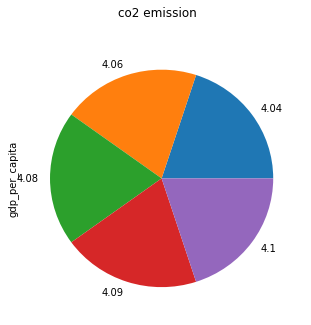

```python
grouped = final.groupby('co2_percapita')
result = grouped.agg(['sum','count','mean','median','min','max'])

math_co2 = grouped.count()
math_co2['gdp_per_capita'].head(5).plot (kind = 'pie', rot=0, subplots=True, figsize=(5, 5), title="co2 emission")

result.head()
```

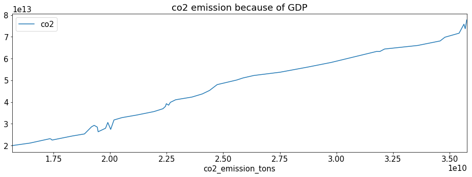

```python
rcParams['font.size'] = 15
rcParams['xtick.labelsize'] = 15
rcParams['ytick.labelsize'] = 15
final.groupby('co2_emission_tons').mean()['GDP_world'].plot (kind = 'line', label='co2', figsize=(16, 5), title = 'co2 emission because of GDP')
plt.legend ()
```

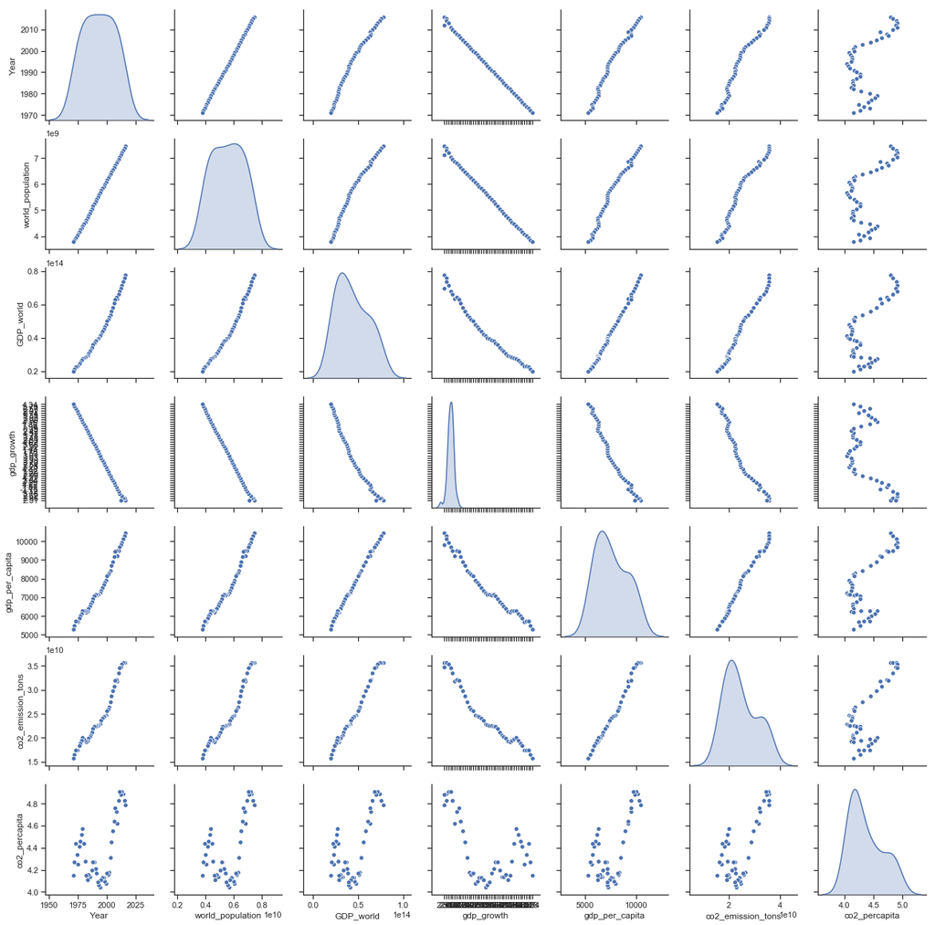

```python
sns.set(style="ticks")
sns.pairplot(final, diag_kind='kde')
```

## 10. Performing the various Regression Functions:

```python
#rcParams['figure.dpi'] = 180
rcParams['lines.linewidth'] = 2
#rcParams['axes.facecolor'] = 'white'
#cParams['patch.edgecolor'] = 'white'                                                  # Applying rc param for clear and visualizable graph.
rcParams['figure.figsize'] = 20,5
rcParams['font.size'] = 15
rcParams['xtick.labelsize'] = 15
rcParams['ytick.labelsize'] = 15
```

```python
rcParams['figure.dpi'] = 200
rcParams['lines.linewidth'] = 0.5
```

### 10. 1) Linear Regression

Performing Linear regression for predicting co2 emission from World Population And GDP of World

```
Intercept          -5.067404e+09
world_population    5.311710e+00
dtype: float64
('R^2 Score =', 0.9419574213355919)
```

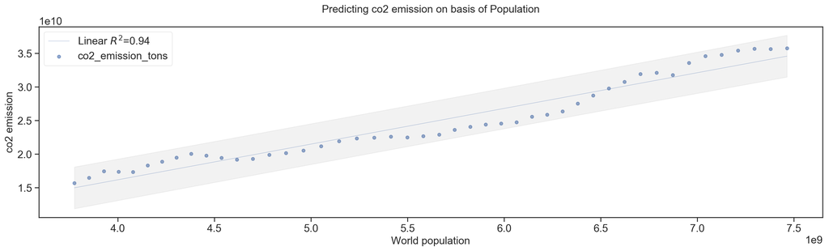

```
Intercept    9.097704e+09
GDP_world    3.533718e-04
dtype: float64
('R^2 Score =', 0.986987830032012)
```

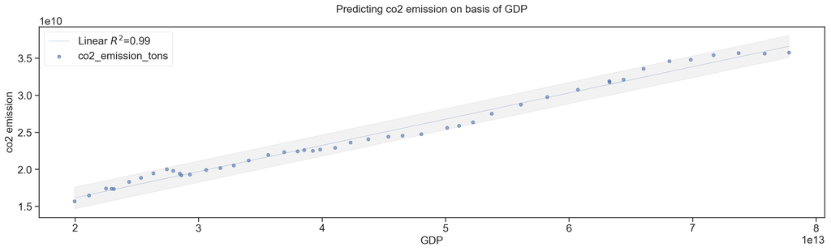

```python
## Poltting linear Regression for co2 emission from world population

import statsmodels.formula.api as smf
from statsmodels.sandbox.regression.predstd import wls_prediction_std

mod = smf.ols(formula="Q('co2_emission_tons') ~ 1+ world_population", data=final).fit()
print(mod.params)
print("R^2 Score =", mod.rsquared)

#confidence = 95% (alpha=0.05)
sdev, lower, upper = wls_prediction_std(mod, alpha=0.05)

plt.scatter(final['world_population'], final['co2_emission_tons'], s=20, alpha=0.6)
plt.plot(final['world_population'], mod.predict(final['world_population']), label='Linear $R^2$=%.2f' % mod.rsquared, alpha=0.5)
plt.fill_between(final['world_population'], lower, upper, color='Grey', alpha=0.1)
#plt.plot(label='Linear $R^2$=%.2f' % mod.rsquared, alpha=0.9)

plt.xlabel('World population', fontdict={'fontsize':15})
plt.ylabel('co2 emission', fontdict={'fontsize':15})
plt.legend(loc='upper left', framealpha=0.4, prop={'size':'medium'})
plt.title('Predicting co2 emission on basis of Population', fontdict={'fontsize':15}, pad=20)
#plt.figure(figsize=(2,2))

plt.show()
mod.summary()

#plt.subplots_adjust( hspace=1)

## Poltting linear Regression for co2 emission from GDP World.

import statsmodels.formula.api as smf
from statsmodels.sandbox.regression.predstd import wls_prediction_std

mod = smf.ols(formula="Q('co2_emission_tons') ~ 1+ GDP_world", data=final).fit()
print(mod.params)
print("R^2 Score =", mod.rsquared)

#confidence = 95% (alpha=0.05)
sdev, lower, upper = wls_prediction_std(mod, alpha=0.05)

plt.scatter(final['GDP_world'], final['co2_emission_tons'], s=20, alpha=0.6)
plt.plot(final['GDP_world'], mod.predict(final['GDP_world']), label='Linear $R^2$=%.2f' % mod.rsquared, alpha=0.5)
plt.fill_between(final['GDP_world'], lower, upper, color='Grey', alpha=0.1)
#plt.plot(label='Linear $R^2$=%.2f' % mod.rsquared, alpha=0.9)

plt.xlabel('GDP', fontdict={'fontsize':15})
plt.ylabel('co2 emission', fontdict={'fontsize':15})
plt.legend(loc='upper left', framealpha=0.4, prop={'size':'medium'})
plt.title('Predicting co2 emission on basis of GDP', fontdict={'fontsize':15}, pad=20)
#plt.figure(figsize=(10,5))

plt.show()
```

### 10.2) Multilinear regression

```
Intercept           1.538365e+10
world_population   -2.268793e+00
GDP_world           4.989641e-04
dtype: float64
('R^2 Score =', 0.991296649358073)
```

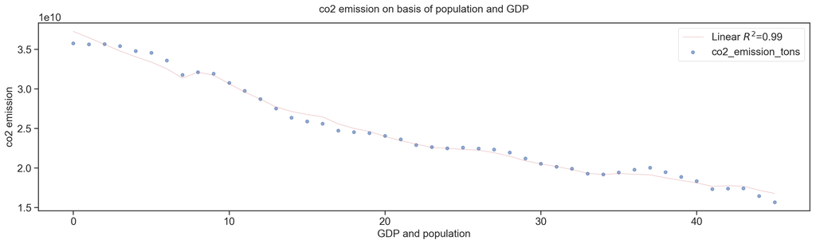

OLS Regression Results

| Dep. Variable: | Q('co2_emission_tons') | R-squared: | 0.991 |
| --- | --- | --- | --- |
| Model: | OLS | Adj. R-squared: | 0.991 |
| Method: | Least Squares | F-statistic: | 2449. |
| Date: | Mon, 20 Apr 2020 | Prob (F-statistic): | 5.05e-45 |
| Time: | 20:01:10 | Log-Likelihood: | -991.88 |
| No. Observations: | 46 | AIC: | 1990. |
| Df Residuals: | 43 | BIC: | 1995. |
| Df Model: | 2 |  |  |
| Covariance Type: | nonrobust |  |  |

|  | coef | std err | t | P>\|t\| | [0.025 | 0.975] |
| --- | --- | --- | --- | --- | --- | --- |
| Intercept | 1.538e+10 | 1.38e+09 | 11.122 | 0.000 | 1.26e+10 | 1.82e+10 |
| world_population | -2.2688 | 0.492 | -4.614 | 0.000 | -3.260 | -1.277 |
| GDP_world | 0.0005 | 3.2e-05 | 15.613 | 0.000 | 0.000 | 0.001 |

| Omnibus: | 2.087 | Durbin-Watson: | 0.323 |
| --- | --- | --- | --- |
| Prob(Omnibus): | 0.352 | Jarque-Bera (JB): | 1.385 |
| Skew: | -0.415 | Prob(JB): | 0.500 |
| Kurtosis: | 3.186 | Cond. No. | 7.65e+14 |

Warnings:  
[1] Standard Errors assume that the covariance matrix of the errors is correctly specified.  
[2] The condition number is large, 7.65e+14. This might indicate that there are  
strong multicollinearity or other numerical problems.

```python
features = ['world_population', 'GDP_world']
X = final[features]
y = final['co2_emission_tons']


mod5 = smf.ols(formula="Q('co2_emission_tons') ~ world_population + GDP_world", data=final).fit()
print(mod5.params)
print("R^2 Score =", mod5.rsquared)
predict_co2_emission_tons = mod5.predict(X)
plt.scatter(final.index, final['co2_emission_tons'], s=20, alpha=0.6)
plt.plot(final.index, predict_co2_emission_tons, 'r-',  label='Linear $R^2$=%.2f' % mod5.rsquared, alpha=0.5)


plt.xlabel('GDP and population', fontdict={'fontsize':15})
plt.ylabel('co2 emission', fontdict={'fontsize':15})
plt.legend(loc='upper right', framealpha=0.5, prop={'size':'medium'})
plt.title('co2 emission on basis of population and GDP', fontdict={'fontsize':15}, pad=15)

plt.show()
mod5.summary()
```

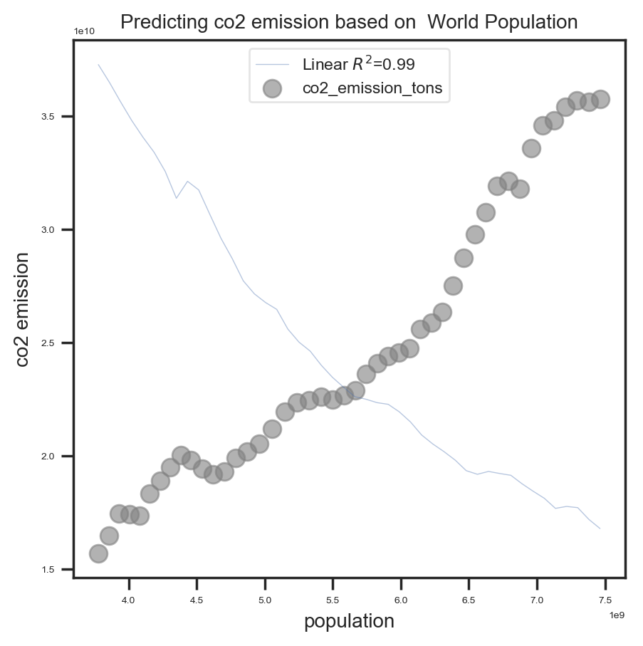

OLS Regression Results

| Dep. Variable: | Q('co2_emission_tons') | R-squared: | 0.987 |
| --- | --- | --- | --- |
| Model: | OLS | Adj. R-squared: | 0.987 |
| Method: | Least Squares | F-statistic: | 3337. |
| Date: | Mon, 20 Apr 2020 | Prob (F-statistic): | 3.95e-43 |
| Time: | 20:01:10 | Log-Likelihood: | -1001.1 |
| No. Observations: | 46 | AIC: | 2006. |
| Df Residuals: | 44 | BIC: | 2010. |
| Df Model: | 1 |  |  |
| Covariance Type: | nonrobust |  |  |

|  | coef | std err | t | P>\|t\| | [0.025 | 0.975] |
| --- | --- | --- | --- | --- | --- | --- |
| Intercept | 9.098e+09 | 2.89e+08 | 31.505 | 0.000 | 8.52e+09 | 9.68e+09 |
| GDP_world | 0.0004 | 6.12e-06 | 57.771 | 0.000 | 0.000 | 0.000 |

| Omnibus: | 0.338 | Durbin-Watson: | 0.232 |
| --- | --- | --- | --- |
| Prob(Omnibus): | 0.845 | Jarque-Bera (JB): | 0.509 |
| Skew: | 0.017 | Prob(JB): | 0.775 |
| Kurtosis: | 2.486 | Cond. No. | 1.32e+14 |

Warnings:  
[1] Standard Errors assume that the covariance matrix of the errors is correctly specified.  
[2] The condition number is large, 1.32e+14. This might indicate that there are  
strong multicollinearity or other numerical problems.

```python
rcParams['font.size'] = 10
rcParams['xtick.labelsize'] = 5
rcParams['ytick.labelsize'] = 5

x = final[['GDP_world','world_population']]
y= final['co2_emission_tons']

wgc = smf.ols(formula='co2_emission_tons ~ 1 + world_population + GDP_world', data=final).fit()


X = pd.DataFrame({'world_population': np.linspace(final.world_population.min(), final.world_population.max(), len(final.world_population))})
plt.figure(figsize=(5,5))
plt.scatter(final.world_population, final.co2_emission_tons, color='Grey',s=80, alpha=0.6)
plt.xlabel('population', fontdict={'fontsize':10}); plt.ylabel('co2 emission', fontdict={'fontsize':10})

plt.plot(X, wgc.predict(x), 'b-', label='Linear $R^2$=%.2f' % mod.rsquared, alpha=0.4)

plt.legend(loc='upper center', framealpha=0.5, prop={'size':'small'})
plt.title("Predicting co2 emission based on  World Population", fontdict={'fontsize':10})
plt.show()
mod.summary()
```

### 10.4) KNN regression

performing distance and uniform model

```python
import re
from sklearn import neighbors
```

```python
rcParams['figure.figsize'] = 5, 5
rcParams['font.size'] = 7
rcParams['figure.dpi'] = 200
rcParams['lines.linewidth'] = 0.5
rcParams['axes.facecolor'] = 'white'
rcParams['patch.edgecolor'] = 'white'
rcParams['font.family'] = 'StixGeneral'
```

```python
x = final.GDP_world.values
x = np.reshape(x,(len(final.GDP_world),1))
y = final.co2_emission_tons.values
y = np.reshape(y,(len(final.co2_emission_tons),1))
```

```python
print len(x)
print len(y)
```

```
46
46
```

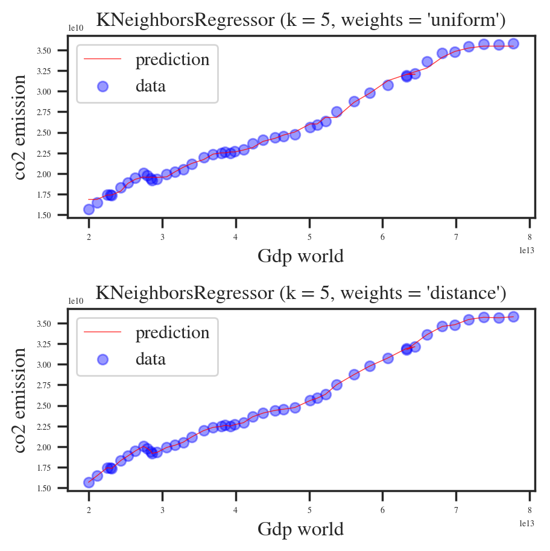

```python
# Plotting Knn regression model graph
x_co2 = np.linspace(1900,2000,500)[:, np.newaxis]
n_neighbors = 5


for i, weights in enumerate(['uniform', 'distance']):
    knn = neighbors.KNeighborsRegressor(n_neighbors, weights=weights)
    y_hat = knn.fit(x, y).predict(x)

    plt.subplot(2, 1, i + 1)
    plt.scatter(x, y, c='Blue', label='data', alpha = 0.4)
    plt.plot(x, y_hat, c='Red', label='prediction', alpha = 0.8)
    plt.axis('tight')
    plt.xlabel('Gdp world')
    plt.ylabel('co2 emission')
    plt.legend(loc='upper left')
    plt.title("KNeighborsRegressor (k = %i, weights = '%s')" % (n_neighbors, weights))
    plt.subplots_adjust( hspace=0.5)

plt.show()
```